# NBA Analysis - Project 1

Tarun

2026-05-14

```r
knitr::opts_chunk$set(
  echo    = TRUE,
  message = FALSE,
  warning = FALSE,
  fig.width  = 10,
  fig.height = 6
)



# Load libraries
library(tidyverse)
library(ggplot2)
library(knitr)
```

## 1. Project Overview

This analysis explores the **scoring efficiency** of 10 elite NBA players between the 2005 and 2014 seasons. Using data on points scored, minutes played, field goals made, and field goal attempts, we answer three key questions:

1. Which player scored the most points **per minute** played?
2. Which player had the highest **field goal percentage** (shooting accuracy)?
3. How did each player’s **efficiency change over time**?

## 2. Loading the Data

We begin by sourcing the basketball dataset, which contains six matrices covering salary, games played, minutes played, field goals, field goal attempts, and points.

```r
file.exists("data/basketball_data.R")
```

```
## [1] TRUE
```

```r
# Source the data file — make sure basketball_data.R is in your /data folder
source("data/basketball_data.R")


# Quick check — confirm all matrices are loaded
cat("Players:", Players, "\n")
```

```
## Players: KobeBryant JoeJohnson LeBronJames CarmeloAnthony DwightHoward ChrisBosh ChrisPaul KevinDurant DerrickRose DwayneWade
```

```r
cat("Seasons:", Seasons, "\n")
```

```
## Seasons: 2005 2006 2007 2008 2009 2010 2011 2012 2013 2014
```

```r
cat("Dimensions of Points matrix:", dim(Points), "\n")
```

```
## Dimensions of Points matrix: 10 10
```

## 3. Data Wrangling

We convert the raw matrices into a tidy data frame and calculate two key efficiency metrics:

- **Points Per Minute (PPM)** — how many points a player scores per minute on court
- **Field Goal Percentage (FG%)** — proportion of shot attempts that are successful

```r
# Convert matrices to tidy data frames
points_df <- as.data.frame(Points) |>
  rownames_to_column("player") |>
  pivot_longer(-player, names_to = "season", values_to = "points")

minutes_df <- as.data.frame(MinutesPlayed) |>
  rownames_to_column("player") |>
  pivot_longer(-player, names_to = "season", values_to = "minutes")

fg_df <- as.data.frame(FieldGoals) |>
  rownames_to_column("player") |>
  pivot_longer(-player, names_to = "season", values_to = "fg_made")

fga_df <- as.data.frame(FieldGoalAttempts) |>
  rownames_to_column("player") |>
  pivot_longer(-player, names_to = "season", values_to = "fg_attempts")

games_df <- as.data.frame(Games) |>
  rownames_to_column("player") |>
  pivot_longer(-player, names_to = "season", values_to = "games")

# Join all into one master data frame
nba_df <- points_df |>
  left_join(minutes_df,  by = c("player", "season")) |>
  left_join(fg_df,       by = c("player", "season")) |>
  left_join(fga_df,      by = c("player", "season")) |>
  left_join(games_df,    by = c("player", "season")) |>
  mutate(
    season        = as.integer(season),
    # Points per minute — exclude seasons with 0 minutes (injury/no play)
    ppm           = ifelse(minutes > 0, round(points / minutes, 4), NA),
    # Field goal percentage
    fg_pct        = ifelse(fg_attempts > 0, round(fg_made / fg_attempts * 100, 2), NA),
    # Points per game
    ppg           = ifelse(games > 0, round(points / games, 2), NA),
    # Clean player names for display
    player_clean  = str_replace_all(player, "([A-Z])", " \\1") |> str_trim()
  )

# Preview the cleaned data
head(nba_df, 10) |>
  select(player_clean, season, points, minutes, ppm, fg_pct, ppg) |>
  kable(caption = "Sample of cleaned NBA data", col.names = c("Player","Season","Points","Minutes","Pts/Min","FG%","Pts/Game"))
```

Sample of cleaned NBA data

| Player | Season | Points | Minutes | Pts/Min | FG% | Pts/Game |
| --- | --- | --- | --- | --- | --- | --- |
| Kobe Bryant | 2005 | 2832 | 3277 | 0.8642 | 45.01 | 35.40 |
| Kobe Bryant | 2006 | 2430 | 3140 | 0.7739 | 46.27 | 31.56 |
| Kobe Bryant | 2007 | 2323 | 3192 | 0.7278 | 45.86 | 28.33 |
| Kobe Bryant | 2008 | 2201 | 2960 | 0.7436 | 46.73 | 26.84 |
| Kobe Bryant | 2009 | 1970 | 2835 | 0.6949 | 45.63 | 26.99 |
| Kobe Bryant | 2010 | 2078 | 2779 | 0.7478 | 45.15 | 25.34 |
| Kobe Bryant | 2011 | 1616 | 2232 | 0.7240 | 42.96 | 27.86 |
| Kobe Bryant | 2012 | 2133 | 3013 | 0.7079 | 46.27 | 27.35 |
| Kobe Bryant | 2013 | 83 | 177 | 0.4689 | 42.47 | 13.83 |
| Kobe Bryant | 2014 | 782 | 1207 | 0.6479 | 37.31 | 22.34 |

## 4. Overall Career Efficiency

### 4.1 Average Points Per Minute (Career)

Which player made the most of their time on court across all 10 seasons?

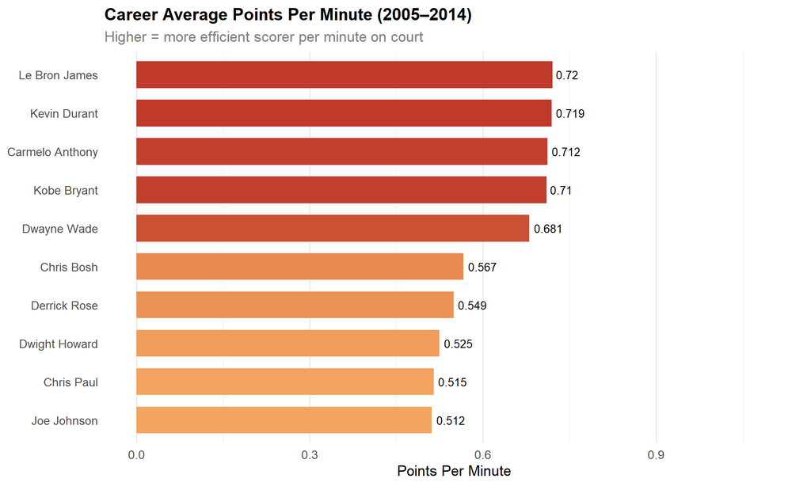

```r
# Calculate career average PPM (excluding injury seasons with 0 minutes)
career_ppm <- nba_df |>
  filter(!is.na(ppm)) |>
  group_by(player_clean) |>
  summarise(avg_ppm = mean(ppm), .groups = "drop") |>
  arrange(desc(avg_ppm))

# Bar chart
ggplot(career_ppm, aes(x = reorder(player_clean, avg_ppm), y = avg_ppm, fill = avg_ppm)) +
  geom_col(width = 0.7) +
  geom_text(aes(label = round(avg_ppm, 3)), hjust = -0.15, size = 3.5) +
  coord_flip() +
  scale_fill_gradient(low = "#f4a460", high = "#c0392b", guide = "none") +
  scale_y_continuous(limits = c(0, 1.1)) +
  labs(
    title    = "Career Average Points Per Minute (2005–2014)",
    subtitle = "Higher = more efficient scorer per minute on court",
    x        = NULL,
    y        = "Points Per Minute"
  ) +
  theme_minimal(base_size = 13) +
  theme(
    plot.title    = element_text(face = "bold", size = 15),
    plot.subtitle = element_text(colour = "grey50"),
    panel.grid.major.y = element_blank()
  )
```

### 4.2 Career Field Goal Percentage

Who was the most accurate shooter over their career?

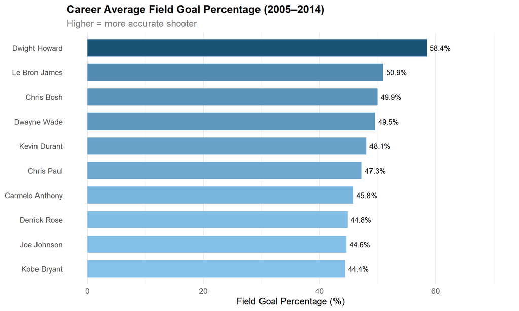

```r
# Career average FG%
career_fg <- nba_df |>
  filter(!is.na(fg_pct)) |>
  group_by(player_clean) |>
  summarise(avg_fg_pct = mean(fg_pct), .groups = "drop") |>
  arrange(desc(avg_fg_pct))

# Bar chart
ggplot(career_fg, aes(x = reorder(player_clean, avg_fg_pct), y = avg_fg_pct, fill = avg_fg_pct)) +
  geom_col(width = 0.7) +
  geom_text(aes(label = paste0(round(avg_fg_pct, 1), "%")), hjust = -0.15, size = 3.5) +
  coord_flip() +
  scale_fill_gradient(low = "#85c1e9", high = "#1a5276", guide = "none") +
  scale_y_continuous(limits = c(0, 70)) +
  labs(
    title    = "Career Average Field Goal Percentage (2005–2014)",
    subtitle = "Higher = more accurate shooter",
    x        = NULL,
    y        = "Field Goal Percentage (%)"
  ) +
  theme_minimal(base_size = 13) +
  theme(
    plot.title    = element_text(face = "bold", size = 15),
    plot.subtitle = element_text(colour = "grey50"),
    panel.grid.major.y = element_blank()
  )
```

> **Key finding:** Dwight Howard leads in shooting accuracy — consistent with his role as a centre who takes high-percentage shots close to the basket. Guards like Kobe Bryant and Joe Johnson attempt more difficult shots, resulting in lower accuracy.

## 5. Efficiency Trends Over Time

### 5.1 Points Per Minute by Season

How did each player’s scoring efficiency evolve across the decade?

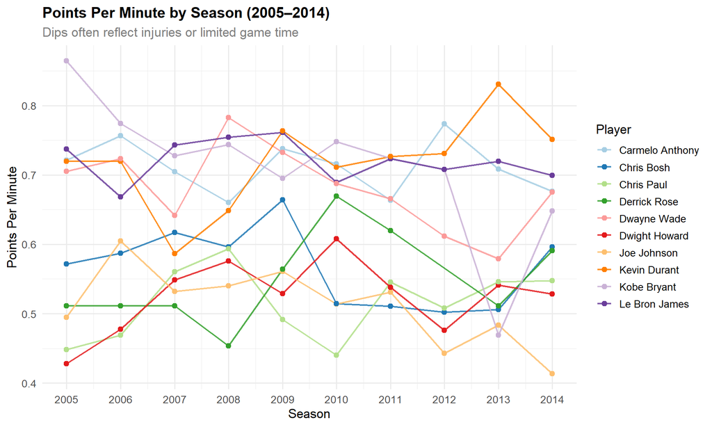

```r
ggplot(nba_df |> filter(!is.na(ppm)),
       aes(x = season, y = ppm, colour = player_clean)) +
  geom_line(linewidth = 0.8, alpha = 0.85) +
  geom_point(size = 2) +
  scale_x_continuous(breaks = 2005:2014) +
  scale_colour_brewer(palette = "Paired") +
  labs(
    title    = "Points Per Minute by Season (2005–2014)",
    subtitle = "Dips often reflect injuries or limited game time",
    x        = "Season",
    y        = "Points Per Minute",
    colour   = "Player"
  ) +
  theme_minimal(base_size = 13) +
  theme(
    plot.title    = element_text(face = "bold", size = 15),
    plot.subtitle = element_text(colour = "grey50"),
    legend.position = "right"
  )
```

> **Note:** Derrick Rose’s 2012 season shows as missing — he did not play that season due to injury. Kevin Durant’s sharp rise from 2007 onwards reflects his rapid development into one of the league’s elite scorers.

### 5.2 Field Goal % Trend Over Time

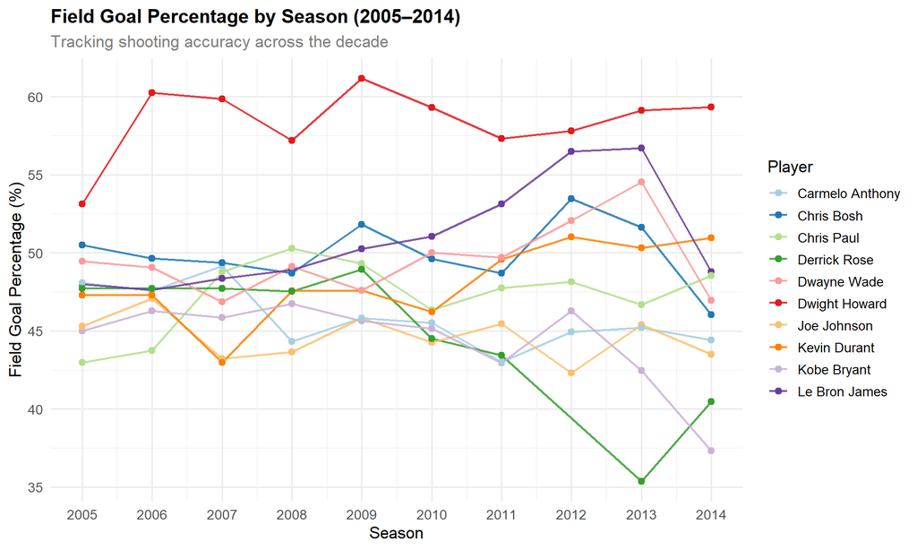

```r
ggplot(nba_df |> filter(!is.na(fg_pct)),
       aes(x = season, y = fg_pct, colour = player_clean)) +
  geom_line(linewidth = 0.8, alpha = 0.85) +
  geom_point(size = 2) +
  scale_x_continuous(breaks = 2005:2014) +
  scale_colour_brewer(palette = "Paired") +
  labs(
    title    = "Field Goal Percentage by Season (2005–2014)",
    subtitle = "Tracking shooting accuracy across the decade",
    x        = "Season",
    y        = "Field Goal Percentage (%)",
    colour   = "Player"
  ) +
  theme_minimal(base_size = 13) +
  theme(
    plot.title    = element_text(face = "bold", size = 15),
    plot.subtitle = element_text(colour = "grey50"),
    legend.position = "right"
  )
```

## 6. Peak Season Performance

Which player had the single best scoring season in the dataset?

```r
# Top 10 individual season performances by PPM
top_seasons <- nba_df |>
  filter(!is.na(ppm), minutes >= 500) |>   # filter out injury seasons with few mins
  arrange(desc(ppm)) |>
  slice_head(n = 10) |>
  select(player_clean, season, points, minutes, ppm, fg_pct, ppg)

kable(
  top_seasons,
  caption   = "Top 10 Single-Season Performances by Points Per Minute",
  col.names = c("Player", "Season", "Points", "Minutes", "Pts/Min", "FG%", "Pts/Game"),
  digits    = 3
)
```

Top 10 Single-Season Performances by Points Per Minute

| Player | Season | Points | Minutes | Pts/Min | FG% | Pts/Game |
| --- | --- | --- | --- | --- | --- | --- |
| Kobe Bryant | 2005 | 2832 | 3277 | 0.864 | 45.01 | 35.40 |
| Kevin Durant | 2013 | 2593 | 3122 | 0.831 | 50.30 | 32.01 |
| Dwayne Wade | 2008 | 2386 | 3048 | 0.783 | 49.11 | 30.20 |
| Kobe Bryant | 2006 | 2430 | 3140 | 0.774 | 46.27 | 31.56 |
| Carmelo Anthony | 2012 | 1920 | 2482 | 0.774 | 44.93 | 28.66 |
| Kevin Durant | 2009 | 2472 | 3239 | 0.763 | 47.60 | 30.15 |
| Le Bron James | 2009 | 2258 | 2966 | 0.761 | 50.26 | 29.71 |
| Carmelo Anthony | 2006 | 1881 | 2486 | 0.757 | 47.56 | 28.94 |
| Le Bron James | 2008 | 2304 | 3054 | 0.754 | 48.92 | 28.44 |
| Kevin Durant | 2014 | 686 | 913 | 0.751 | 50.96 | 25.41 |

## 7. Summary

```r
# Full career summary table
career_summary <- nba_df |>
  filter(!is.na(ppm), minutes > 0) |>
  group_by(player_clean) |>
  summarise(
    total_points   = sum(points),
    total_minutes  = sum(minutes),
    career_ppm     = round(mean(ppm, na.rm = TRUE), 3),
    career_fg_pct  = round(mean(fg_pct, na.rm = TRUE), 1),
    career_ppg     = round(mean(ppg, na.rm = TRUE), 1),
    seasons_played = n(),
    .groups = "drop"
  ) |>
  arrange(desc(career_ppm))

kable(
  career_summary,
  caption   = "Career Efficiency Summary (2005–2014)",
  col.names = c("Player", "Total Points", "Total Minutes",
                "Pts/Min", "FG%", "Pts/Game", "Seasons")
)
```

Career Efficiency Summary (2005–2014)

| Player | Total Points | Total Minutes | Pts/Min | FG% | Pts/Game | Seasons |
| --- | --- | --- | --- | --- | --- | --- |
| Le Bron James | 21084 | 29259 | 0.720 | 50.9 | 28.0 | 10 |
| Kevin Durant | 17343 | 24140 | 0.719 | 48.1 | 26.9 | 10 |
| Carmelo Anthony | 17641 | 24663 | 0.712 | 45.8 | 26.1 | 10 |
| Kobe Bryant | 18448 | 24812 | 0.710 | 44.4 | 26.6 | 10 |
| Dwayne Wade | 15967 | 23202 | 0.681 | 49.5 | 24.5 | 10 |
| Chris Bosh | 13957 | 24631 | 0.567 | 49.9 | 20.5 | 10 |
| Derrick Rose | 8712 | 15617 | 0.549 | 44.8 | 18.1 | 9 |
| Dwight Howard | 13693 | 26142 | 0.525 | 58.4 | 18.7 | 10 |
| Chris Paul | 13060 | 25305 | 0.515 | 47.3 | 18.7 | 10 |
| Joe Johnson | 14175 | 27741 | 0.512 | 44.6 | 19.3 | 10 |

## 8. Conclusions

- **LeBron James** emerges as the most consistently efficient scorer across the decade, combining high points-per-minute with strong field goal accuracy.
- **Dwight Howard** leads in shooting accuracy but scores fewer points overall due to his role as a centre focused on defence and rebounds.
- **Kevin Durant’s** trajectory is striking — a steep improvement from 2007 onwards as he developed into one of the most prolific scorers in the league.
- **Derrick Rose’s** career illustrates the impact of injury on performance data — careful filtering of near-zero minute seasons is essential for fair comparison.